# particle_placement_analysis.R

# Pruning (if necessary)

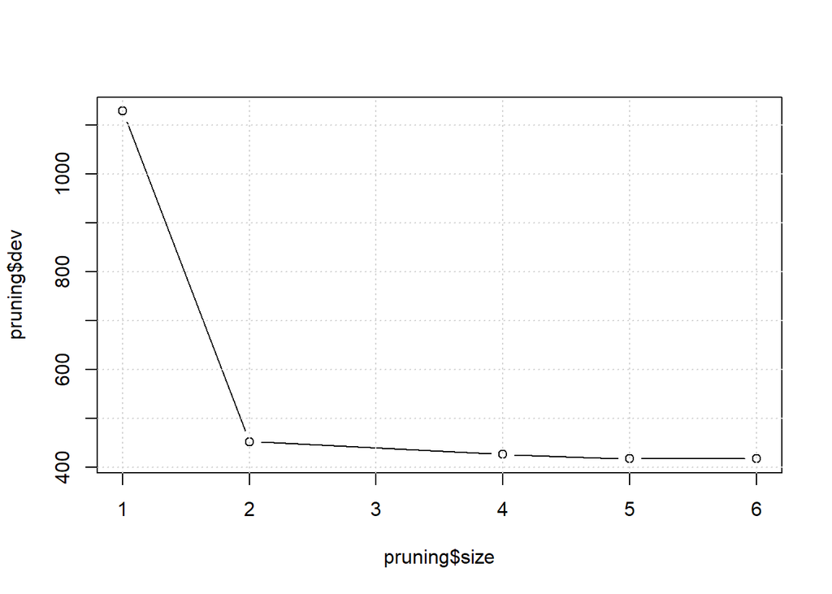

```r
# based on number of misclassifications
pruning <- cv.tree(cart.1, FUN = prune.misclass)

plot(pruning$size, pruning$dev, type="b"); grid()
```

The deviances are lowest for 5 and 6 nodes but 6 is the same tree… so using the tree with 5 nodes

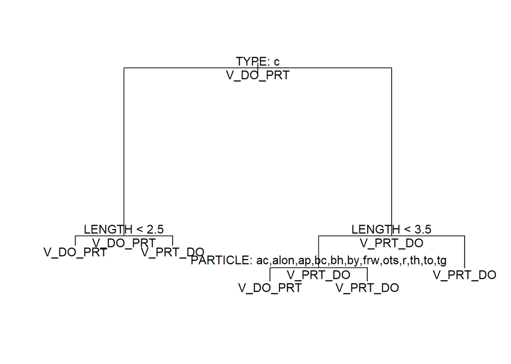

```r
# pruned to 5 terminal nodes
cart.1.pruned <- prune.misclass(cart.1, best=5)

# plot the new, pruned tree
plot(cart.1.pruned)
text(cart.1.pruned, pretty = 1, all=TRUE)
```

```r
# still really messy

# new tree's performance
predictions.cat.pruned <- predict(cart.1.pruned, type="class")
```

## Testing new accuracy

```r
table(CONSTRUCTION, predictions.cat.pruned)
```

```
##             predictions.cat.pruned
## CONSTRUCTION V_DO_PRT V_PRT_DO
##     V_DO_PRT      856      336
##     V_PRT_DO       37     1092
```

```r
# numbers in the table are actually exactly the same as original tree
# so all calculations will remain the same
# ie:
```

**Accuracy**:

```r
(856 + 1092) / length(predictions.cat)
```

```
## [1] 0.8392934
```

**Precision**:

```r
1092 / (1092 + 336)
```

```
## [1] 0.7647059
```

**Recall/sensitivity**:

```r
1092 / (1092 + 37)
```

```
## [1] 0.9672276
```

**F**:

```r
2*((0.7647059*0.9672276)/(0.7647059+0.9672276))
```

```
## [1] 0.8541259
```

## Testing with subsets of data

```r
# same training data as earlier and the pruned tree
cart.validation.training.1 <- tree(formula(cart.1.pruned),
                                   data=x[sampler=="training",])

# making predictions for test data based on training data
predictions.validation.test.1 <- predict(cart.validation.training.1,
                                         newdata=x[sampler=="test",],
                                         type="class")

sum(predictions.validation.test.1 ==
        CONSTRUCTION[sampler=="test"]) /
    length(predictions.validation.test.1)
```

```
## [1] 0.8209983
```

```r
# also same number
```

## Pruning more

seemed like 4 nodes also was pretty low let’s try that

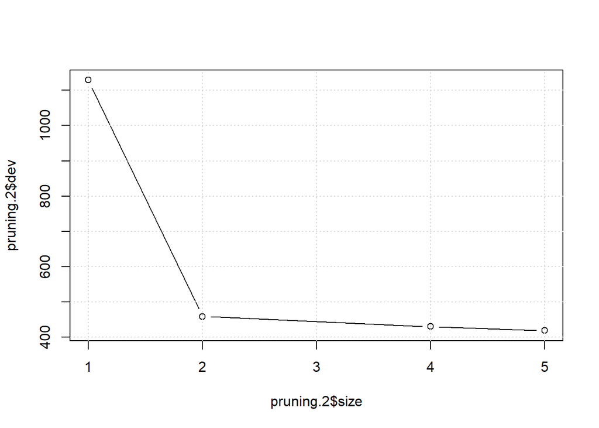

```r
pruning.2 <- cv.tree(cart.1.pruned, FUN = prune.misclass)

plot(pruning.2$size, pruning.2$dev, type="b"); grid()
```

The deviances are lowest for 4 and 5 nodes but 5 is the same tree… so using the tree with 4 nodes

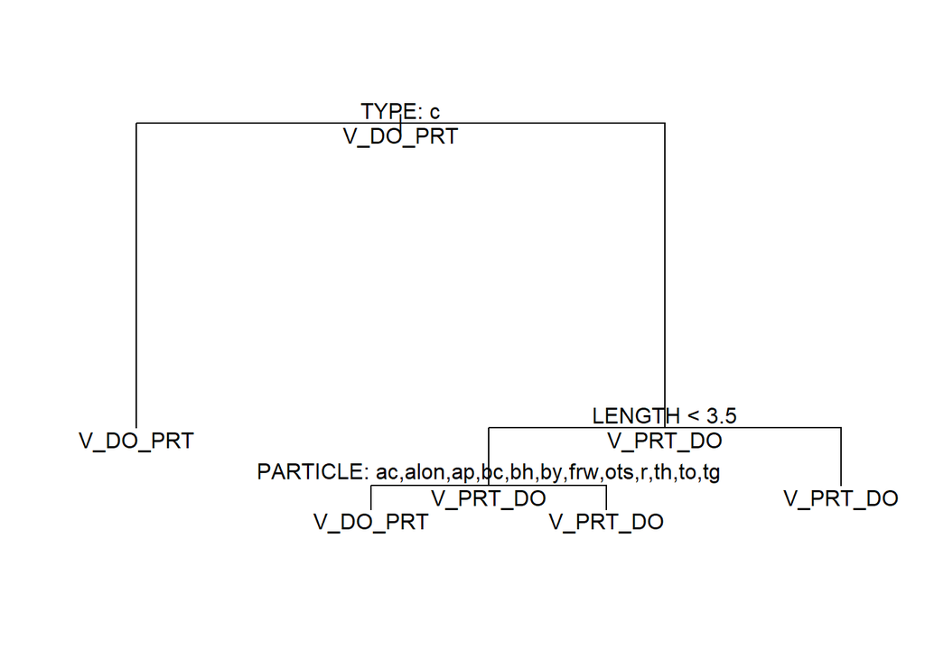

```r
# pruned to 4 terminal nodes
cart.2.pruned <- prune.misclass(cart.1.pruned, best=4)

# plot the new, pruned tree
plot(cart.2.pruned)
    text(cart.2.pruned, pretty = 1, all=TRUE)
```

```r
# still really messy

# new tree's performance
predictions.cat.pruned.2 <- predict(cart.2.pruned, type="class")
```

### Testing new accuracy

```r
table(CONSTRUCTION, predictions.cat.pruned.2)
```

```
##             predictions.cat.pruned.2
## CONSTRUCTION V_DO_PRT V_PRT_DO
##     V_DO_PRT      859      333
##     V_PRT_DO       47     1082
```

```r
# very slightly different numbers
# same calculations as with original tree:
```

**Accuracy**:

```r
(859 + 1082) / length(predictions.cat.pruned.2)
```

```
## [1] 0.8362775
```

```r
# was 0.8392934
# negligible difference
```

**Precision**:

```r
1082 / (1082 + 333)
```

```
## [1] 0.7646643
```

```r
# was 0.7647059
# negligible difference
```

**Recall/sensitivity**:

```r
1082 / (1082 + 47)
```

```
## [1] 0.9583702
```

```r
# was 0.9672276
# negligible difference
```

**F**:

```r
2*((0.7646643*0.9583702)/(0.7646643+0.9583702))
```

```
## [1] 0.8506289
```

```r
# was 0.8541259
# negligible difference
```

### Testing with subsets of data

```r
# same training data as earlier and the pruned tree
cart.validation.training.2 <- tree(formula(cart.2.pruned),
                                   data=x[sampler=="training",])

# making predictions for test data based on training data
predictions.validation.test.2 <- predict(cart.validation.training.2,
                                         newdata=x[sampler=="test",],
                                         type="class")

sum(predictions.validation.test.2 ==
        CONSTRUCTION[sampler=="test"]) /
    length(predictions.validation.test.1)
```

```
## [1] 0.8209983
```

```r
# was 0.8209983
# no difference

# so pruning even further sacrifices basically nothing,
# but improves tree's simplicity/readability
```

# Conclusion

The third tree (cart.2.pruned) pruned to 4 terminal nodes has okay classification accuracy (0.8362775) but very high recall/sensitivity (0.9583702). Pruning the original tree (cart.1) did not increase prediction accuracy on the training/testing set at all though. It did not decrease it though, so overall pruning it a little was good in that it decreased the tree’s complications and made it easier to interpret.  
The tree shows that type is an influential predictor, given that the lines to the next nodes are relatively very long.  
It also shows that even with six independent variables, some with many levels, only a few of them really make a difference in predictions. Type, length, and particle influence prediction choices, and only a subset of those variables at that. Every other variable/variable level not included in the tree can be assumed to not have enough predictive power to be included. So things like register and subregister are not influential at all.